# PDX: Drug trails

Olaparib

Alistair Martin

Last modified: 16 Mar 2018

# Load libraries, functions and data

[output not shown]

# QC

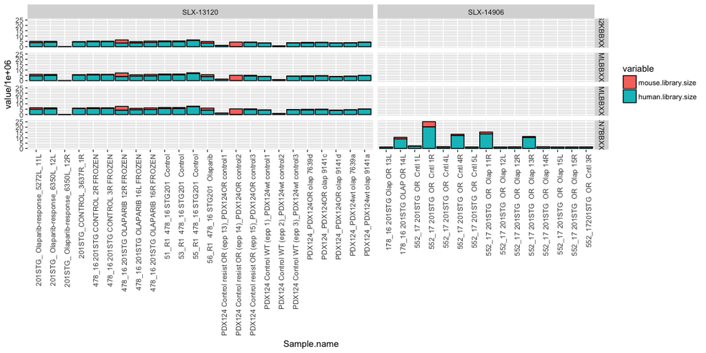

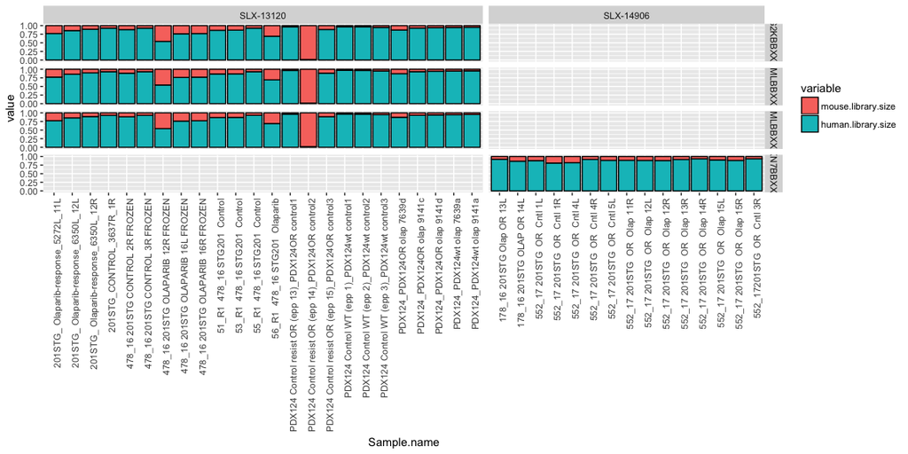

```r
read.depth.plots(rnaseq$meta)
```

We see that there is spontaneous mouse tumour within SLX-13120, as well as some samples that have a large fraction of mouse stroma, and finallyone sample failed completely. The cellularity could be merely due to the PDX sample/model having a low cellularity, meaning that more stroma is present in these compared to other PDX samples/models. We should still remove the mouse tumour and the failed run, following which we can merge the lanes.

Within SLX-14906, we see that the pool was highly imbalanced, and that five samples dominated the sequencing. The other samples have about roughly 1.2 million reads each; which is below the recommended amount for DE analysis (>5 mil). We will still attempt the analysis regardless.

```r
rnaseq <- subset.PDX(rnaseq, rnaseq$meta[,!(Sample.name %in% c("PDX124 Control resist OR (epp 14)_PDX124OR control2","201STG_ Olaparib-response_6350L_12R"))])
rnaseq <- merge.PDX(rnaseq)
rnaseq$meta <- merge(rnaseq$meta,meta,sort=F)
rnaseq$meta[,merged.lanes:=as.numeric(as.factor(merged.lanes))]
```

Let’s just see whether there is a difference in the PDXs cellularity

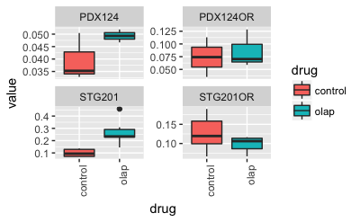

```r
x <- melt(rnaseq$meta,id.vars=c("Sample.name","pdx","drug"),measure.vars = c("mouse.library.size","human.library.size"))
x[,value:=value/sum(value),Sample.name]
ggplot(x[variable=="mouse.library.size"]) + aes(x=drug,y=value,fill=drug) + geom_boxplot() + theme(axis.text.x=element_text(angle=90,hjust=1)) + facet_wrap(~pdx,scales = "free_y")
```

Treatment with olap is clearly effecting the samples cellularity, both in PDX124 and STG201. Note that it isn’t affecting the cellularity in resitant model. Is this explained by the treatment “killing” the cancerous tissue?

#Key questions

- Are there any systematic differences between the control and treated groups?
- Are there any traits/markers that define the speed with which resistance is devloped in the treated groups?
- Is the transcriptome of the control group similar between mice?
- Is resistance developed in different manners between the treated samples?

# PCAs

[output not shown]

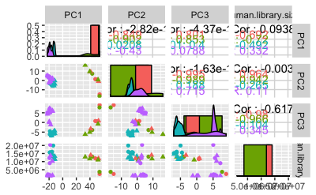

```r
pca <- pca.run(rnaseq$human)
pca <- cbind(rnaseq$meta,pca)
pca$merged.lanes <- factor(pca$merged.lanes)
ggpairs(pca, columns=c('PC1', 'PC2', 'PC3', "human.library.size"),mapping=aes(color=pdx,shape=drug), upper=list(continuous='cor'))
```

[output not shown]

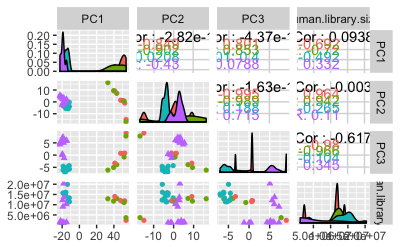

```r
ggpairs(pca, columns=c('PC1', 'PC2', 'PC3', "human.library.size"),mapping=aes(color=pdx,shape=merged.lanes), upper=list(continuous='cor'))
```

Clear differences between the two PDX models are apparent which overshadow any defined difference between the treatment arms. Let us account from that by considering models as a batch effect.

[output not shown]

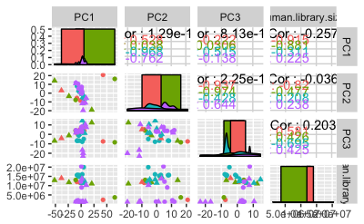

```r
y <- pca.prep(rnaseq$human)
y <- removeBatchEffect(y, batch=rnaseq$meta$pdx)
pca <- prcomp(t(y),scale=T)
pca <- cbind(rnaseq$meta,pca$x)
pca$merged.lanes <- factor(pca$merged.lanes)
ggpairs(pca, columns=c('PC1', 'PC2', 'PC3', "human.library.size"),mapping=aes(color=pdx,shape=drug), upper=list(continuous='cor'))
```

[output not shown]

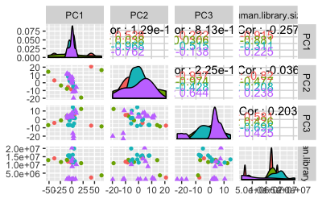

```r
ggpairs(pca, columns=c('PC1', 'PC2', 'PC3', "human.library.size"),mapping=aes(color=pdx,shape=merged.lanes), upper=list(continuous='cor'))
```

These plots just seem messy and their is no apparent grouping w.r.t. treatment, sequeincing depth, or sequencing runs. Let’s plot each of the models seperatly. Note that the top 1000 most variable genes and principal compoenents will differ between them when treated individually.

[output not shown]

[output cut: 44 more lines]

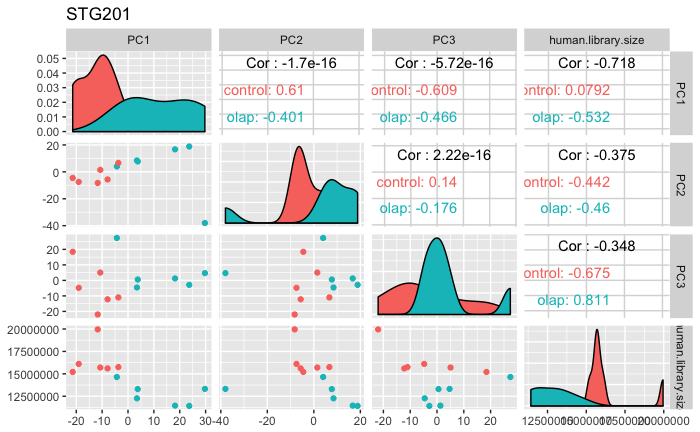

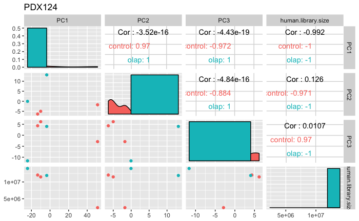

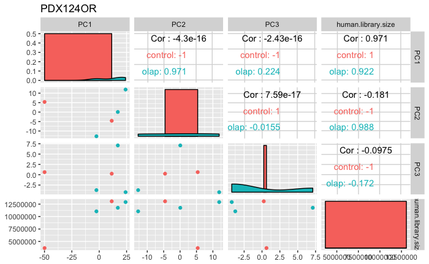

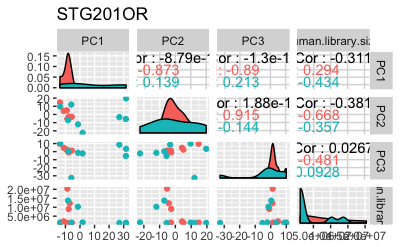

```r
for(PDX in unique(rnaseq$meta$pdx)){
  x <- subset.PDX(rnaseq, rnaseq$meta[,pdx == PDX])
  pca <- pca.run(x$human)
  pca <- cbind(x$meta,pca)
  print(ggpairs(pca, columns=c('PC1', 'PC2', 'PC3', "human.library.size"),mapping=aes(color=drug), upper=list(continuous='cor'))  + ggtitle(PDX))
}
```

By looking within models, we see good seperation between treatment arms in the niave models, while little seperation in the resitant ones. This is as expected.

Seperatly there is an outlier in the STG201 model, which in itself was performed over two experimental batches. In addition, one sample of STG201 was from a tumour implanted in a different mouse brood. This is the likely culprint. Let’s identify it and remove it.

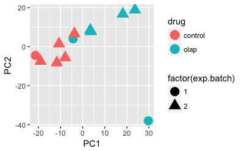

```r
x <- subset.PDX(rnaseq, rnaseq$meta[,pdx == "STG201"])
pca <- pca.run(x$human)
pca <- cbind(x$meta,pca)
ggplot(pca) + aes(x=PC1,y=PC2,col=drug,shape=factor(exp.batch)) + geom_point(size=5)
```

```r
outlier <- pca[PC1 > 25 & PC2 < -20,Sample.name]
outlier
```

```
[1] "201STG_ Olaparib-response_5272L_11L"
```

```r
rnaseq <- subset.PDX(rnaseq,rnaseq$meta[,Sample.name!=outlier])
```

# All data

First, let us break down our PDX model types into the base type and whether it is the resitant model. Then we will construct our meta vectors.

```r
rnaseq$meta[,resistant:=factor(substr(pdx,nchar(pdx)-1,nchar(pdx))=="OR")]
levels(rnaseq$meta$resistant) <- c("Niave","Resistant")
rnaseq$meta[resistant=="Resistant",pdx:=substr(pdx,0,nchar(pdx)-2)]
drug <- make.names(rnaseq$meta$drug)
pdx <- make.names(rnaseq$meta$pdx)
resistant <- make.names(rnaseq$meta$resistant)
exp.batch <- make.names(rnaseq$meta$exp.batch)
sequencing <- make.names(rnaseq$meta$merged.lanes)
```

## Model: ~ 0 + drug:(pdx*resistant)

Let us look at the tissue types individually to see if they react differently.

```r
d <- model.matrix(~ 0 + drug:interaction(pdx,resistant))
d <- d[,colSums(d)!=0]
n <- length(unique(interaction(pdx,resistant)))
c <- matrix(0,dim(d)[2],n)
c[cbind(seq(1,by=2,length.out=n),1:n)] <- -1
c[cbind(seq(2,by=2,length.out=n),1:n)] <- 1
colnames(c) <- paste(sort(unique(interaction(pdx,resistant))),"Olap.minus.control",sep=":")
rownames(c) <- colnames(d)
c
```

```
                                                        PDX124.Niave:Olap.minus.control STG201.Niave:Olap.minus.control PDX124.Resistant:Olap.minus.control STG201.Resistant:Olap.minus.control
drugcontrol:interaction(pdx, resistant)PDX124.Niave                                  -1                               0                                   0                                   0
drugolap:interaction(pdx, resistant)PDX124.Niave                                      1                               0                                   0                                   0
drugcontrol:interaction(pdx, resistant)STG201.Niave                                   0                              -1                                   0                                   0
drugolap:interaction(pdx, resistant)STG201.Niave                                      0                               1                                   0                                   0
drugcontrol:interaction(pdx, resistant)PDX124.Resistant                               0                               0                                  -1                                   0
drugolap:interaction(pdx, resistant)PDX124.Resistant                                  0                               0                                   1                                   0
drugcontrol:interaction(pdx, resistant)STG201.Resistant                               0                               0                                   0                                  -1
drugolap:interaction(pdx, resistant)STG201.Resistant                                  0                               0                                   0                                   1
```

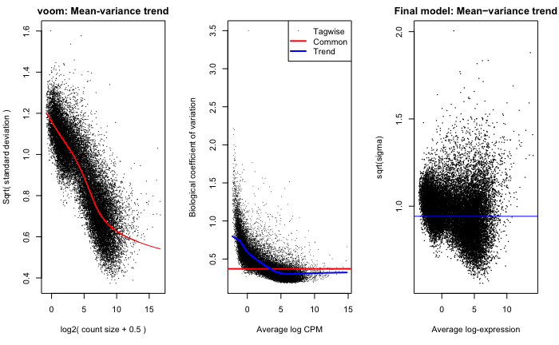

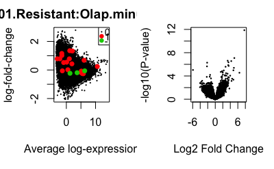

```r
DE.data <- DE.run(rnaseq$human,d,2,cont.matrix=c)
```

```r
#Table of DE genes
DE <- decideTest.annotated.DE(DE.data$efit,p.val = 0.05)
DE
```

| ENSEMBL | PDX124.Niave:Olap.minus.control | STG201.Niave:Olap.minus.control | PDX124.Resistant:Olap.minus.control | STG201.Resistant:Olap.minus.control | ENTREZID | SYMBOL | GENENAME |
| --- | --- | --- | --- | --- | --- | --- | --- |
| ENSG00000187730 | 0 | 1 | 0 | 0 | 2563 | GABRD | gamma-aminobutyric acid type A receptor delta subunit |
| ENSG00000116254 | 0 | 1 | 0 | 0 | 26038 | CHD5 | chromodomain helicase DNA binding protein 5 |
| ENSG00000069812 | 0 | 1 | 0 | 0 | 54626 | HES2 | hes family bHLH transcription factor 2 |
| ENSG00000162551 | -1 | 0 | 0 | 0 | 249 | ALPL | alkaline phosphatase, liver/bone/kidney |
| ENSG00000121769 | 0 | 1 | 0 | 0 | 2170 | FABP3 | fatty acid binding protein 3 |
| ENSG00000117407 | 0 | -1 | 0 | 0 | 9048 | ARTN | artemin |
| ENSG00000117472 | 0 | 1 | 0 | 0 | 10103 | TSPAN1 | tetraspanin 1 |
| ENSG00000174348 | 0 | 1 | 0 | 0 | 127435 | PODN | podocan |
| ENSG00000116133 | 0 | -1 | 0 | 0 | 1718 | DHCR24 | 24-dehydrocholesterol reductase |
| ENSG00000137959 | 1 | 0 | 0 | 0 | 10964 | IFI44L | interferon induced protein 44 like |

[output cut: 114 more lines]

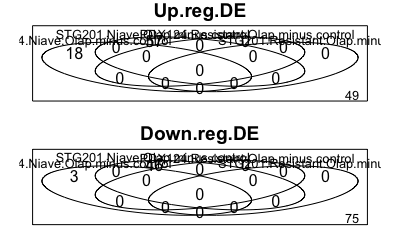

```r
#VennDiagrms of DE genes
vennDiagram.paired(DE[,2:(n+1)])
```

If we treat all models individually we get no overlap bewteen the DE genes. Notably, or maybe as to be expected, DE genes are only found in the non-resistant models. This shows that we should always model the treatment effect as differing between resistant and non-resistant samples.

## Model: ~ 0 + drug * resistant * pdx

This model makes no presumptions about how the drug interacts w.r.t. resistance and PDX model. However, by constructing the model in such a manner, the increase in power to the above model means that we may find overlap in genes/pathways.

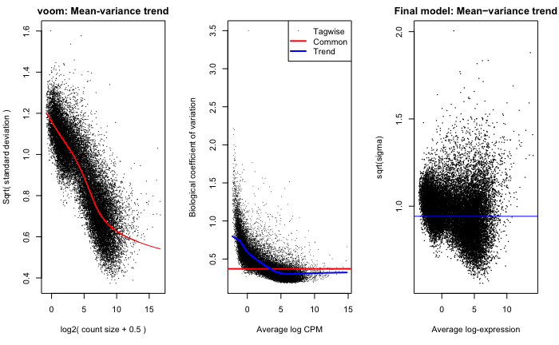

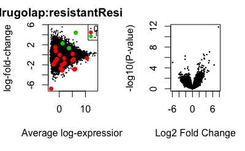

```r
#d <- model.matrix(~ drug * resistant * pdx  + sequencing) The sequencing batch effect compounds the STG201OR vs STG201 comparison. We ignore it, but are naturally worried.
d <- model.matrix(~ drug * resistant * pdx)
d <- d[,colSums(d)!=0]
#cont.matrix <- matrix(c(-1,1,rep(0,dim(d)[2]-2)), dim(d)[2], 1)
#colnames(cont.matrix) <- c("Olap.minus.control")
#rownames(cont.matrix) <- colnames(d)
#cont.matrix
coefs <- c(2,3,5)
#Perform DE
DE.data <- DE.run(rnaseq$human,d,2,coefs = coefs)
```

```r
dt <- decideTests(DE.data$efit,p.value = 0.05)
summary(dt)
```

```
       drugolap resistantResistant drugolap:resistantResistant
Down          3                 28                           0
NotSig    20570              20546                       20591
Up           18                 17                           0
```

```r
i <- which(dt[,1]!=0 | dt[,2]!=0)
dt <- as.data.frame(dt[i,])
dt$symbol <-  getBM(attributes=c('external_gene_name'),filters='ensembl_gene_id',mart=hg19.ensembl,values=rownames(dt))$external_gene_name
dt
```

[output not shown]

[output cut: 53 more lines]

We find a multiple genes that define the drug response and the gaining of resistance that are shared between models.

### DE Heatmaps

[output not shown]

[output cut: 16 more lines]

[output not shown]

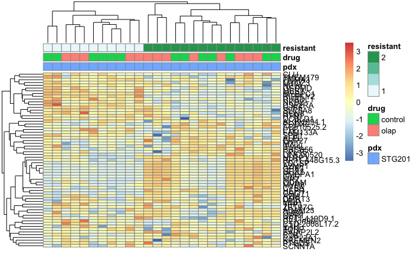

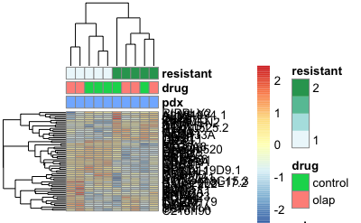

```r
for(PDX in unique(pdx)){
  i <- match(rownames(dt),rownames(DE.data$v$E))
  j <- which(pdx == PDX)
  y <- DE.data$v$E[i,j]
  labels.col <- rep("",length(j))
  labels.row <- dt$symbol
  ann.col <- as.data.frame(rnaseq$meta[j,.(pdx,drug,resistant=as.numeric(resistant))])
  rownames(ann.col) <- rnaseq$meta[j,Sample.name]
  print(pheatmap(y,labels_col=labels.col,labels_row=labels.row,annotation_col = ann.col,scale="row"))
}
```

### GSEA c2

```r
for(i in 1:3){
  gsea <- GSEA.run(DE.data$v,d,i,Hs.c2,0.05)
  print(gsea[Direction=="Up",.(colnames(dt)[i],rn,NGenes,Direction,FDR)])
  print(gsea[Direction=="Down",.(colnames(dt)[i],rn,NGenes,Direction,FDR)])
}
```

| V1 | rn | NGenes | Direction | FDR |
| --- | --- | --- | --- | --- |
| drugolap | KEGG_RIBOSOME | 85 | Up | 6.805278e-07 |
| drugolap | REACTOME_PEPTIDE_CHAIN_ELONGATION | 85 | Up | 6.805278e-07 |
| drugolap | REACTOME_INFLUENZA_VIRAL_RNA_TRANSCRIPTION_AND_REPLICATION | 100 | Up | 9.450330e-07 |
| drugolap | REACTOME_3_UTR_MEDIATED_TRANSLATIONAL_REGULATION | 105 | Up | 9.450330e-07 |
| drugolap | REACTOME_SRP_DEPENDENT_COTRANSLATIONAL_PROTEIN_TARGETING_TO_MEMBRANE | 108 | Up | 1.389297e-06 |
| drugolap | REACTOME_TRANSLATION | 144 | Up | 1.507042e-06 |
| drugolap | REACTOME_NONSENSE_MEDIATED_DECAY_ENHANCED_BY_THE_EXON_JUNCTION_COMPLEX | 105 | Up | 1.507042e-06 |
| drugolap | REACTOME_FORMATION_OF_THE_TERNARY_COMPLEX_AND_SUBSEQUENTLY_THE_43S_COMPLEX | 48 | Up | 2.541185e-06 |
| drugolap | REACTOME_INFLUENZA_LIFE_CYCLE | 134 | Up | 5.451228e-06 |
| drugolap | REACTOME_ACTIVATION_OF_THE_MRNA_UPON_BINDING_OF_THE_CAP_BINDING_COMPLEX_AND_EIFS_AND_SUBSEQUENT_BINDING_TO_43S | 56 | Up | 8.801112e-06 |

[output cut: 895 more lines]

| V1 | rn | NGenes | Direction | FDR |
| --- | --- | --- | --- | --- |
| drugolap | REACTOME_AMINE_LIGAND_BINDING_RECEPTORS | 13 | Down | 0.02878954 |
| drugolap | MIKKELSEN_ES_HCP_WITH_H3K27ME3 | 21 | Down | 0.02972032 |
| drugolap | KONDO_PROSTATE_CANCER_WITH_H3K27ME3 | 66 | Down | 0.03321600 |
| drugolap | REACTOME_AMINE_DERIVED_HORMONES | 7 | Down | 0.04000236 |
| drugolap | KEGG_NEUROACTIVE_LIGAND_RECEPTOR_INTERACTION | 117 | Down | 0.04087178 |
| drugolap | BIOCARTA_EXTRINSIC_PATHWAY | 9 | Down | 0.04289383 |
| drugolap | BIOCARTA_DC_PATHWAY | 7 | Down | 0.04362946 |
| drugolap | REACTOME_CLASS_A1_RHODOPSIN_LIKE_RECEPTORS | 120 | Down | 0.04388902 |

| V1 | rn | NGenes | Direction | FDR |
| --- | --- | --- | --- | --- |
| resistantResistant | BOWIE_RESPONSE_TO_TAMOXIFEN | 16 | Up | 4.482654e-07 |
| resistantResistant | MOSERLE_IFNA_RESPONSE | 29 | Up | 3.202643e-06 |
| resistantResistant | ZHANG_INTERFERON_RESPONSE | 20 | Up | 1.268302e-05 |
| resistantResistant | FARMER_BREAST_CANCER_CLUSTER_1 | 21 | Up | 1.934363e-05 |
| resistantResistant | EINAV_INTERFERON_SIGNATURE_IN_CANCER | 25 | Up | 1.803297e-04 |
| resistantResistant | BOWIE_RESPONSE_TO_EXTRACELLULAR_MATRIX | 16 | Up | 2.865748e-04 |
| resistantResistant | ROETH_TERT_TARGETS_UP | 14 | Up | 1.009600e-03 |
| resistantResistant | GRANDVAUX_IFN_RESPONSE_NOT_VIA_IRF3 | 13 | Up | 1.229190e-03 |
| resistantResistant | BENNETT_SYSTEMIC_LUPUS_ERYTHEMATOSUS | 26 | Up | 1.345305e-03 |
| resistantResistant | REACTOME_INTERFERON_ALPHA_BETA_SIGNALING | 47 | Up | 1.440789e-03 |

[output cut: 12 more lines]

| V1 | rn | NGenes | Direction | FDR |
| --- | --- | --- | --- | --- |

| V1 | rn | NGenes | Direction | FDR |
| --- | --- | --- | --- | --- |

| V1 | rn | NGenes | Direction | FDR |
| --- | --- | --- | --- | --- |

We find that the treatment has a large effect on the transcriptome, disrupting many pathways (921 reported DE). In contrast, the gaining of the resistant phenotype leads to only a few pathways changing (22 reported DE).

### GSEA c6

```r
for(i in 1:3){
  gsea <- GSEA.run(DE.data$v,d,i,Hs.c6,0.05)
  print(gsea[Direction=="Up",.(colnames(dt)[i],rn,NGenes,Direction,FDR)])
  print(gsea[Direction=="Down",.(colnames(dt)[i],rn,NGenes,Direction,FDR)])
}
```

| V1 | rn | NGenes | Direction | FDR |
| --- | --- | --- | --- | --- |
| drugolap | SIRNA_EIF4GI_UP | 90 | Up | 0.02183515 |

| V1 | rn | NGenes | Direction | FDR |
| --- | --- | --- | --- | --- |

| V1 | rn | NGenes | Direction | FDR |
| --- | --- | --- | --- | --- |

| V1 | rn | NGenes | Direction | FDR |
| --- | --- | --- | --- | --- |

| V1 | rn | NGenes | Direction | FDR |
| --- | --- | --- | --- | --- |

| V1 | rn | NGenes | Direction | FDR |
| --- | --- | --- | --- | --- |

### Genes of interest (no drug) [Harveer (Steve Jackson)]

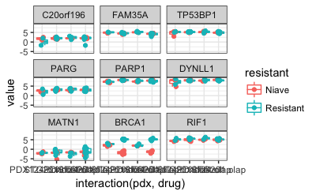

```r
genes <- c("FAM35A","C20orf196","TP53BP1","RIF1","DYNLL1","TEN1","PARG","PARP1","MATN1","BRCA1")
genes.ensembl <- getBM(attributes=c('ensembl_gene_id',"external_gene_name"),filters='external_gene_name',mart=hg19.ensembl,values=genes)
genes.ensembl$row.id <- match(genes.ensembl$ensembl_gene_id,rownames(DE.data$v$E))
genes.ensembl <- genes.ensembl[!is.na(genes.ensembl$row.id),]

x <- t(DE.data$v$E[genes.ensembl$row.id,])
#x <- t(removeBatchEffect(t(x), batch=sequencing))
colnames(x) <- genes.ensembl$external_gene_name
x <- cbind(rnaseq$meta[,.(pdx,resistant,drug)],x)
x <- melt(x,id.vars = c("pdx","resistant","drug"))
ggplot(x) + aes(x=interaction(pdx,drug),y=value,colour=resistant) + geom_boxplot(outlier.shape = NA) + geom_jitter(width=0.1) + facet_wrap(~variable)  + theme_bw()
```

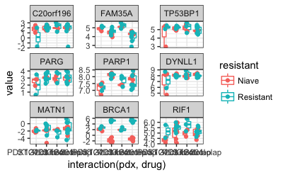

```r
ggplot(x) + aes(x=interaction(pdx,drug),y=value,colour=resistant) + geom_boxplot(outlier.shape = NA) + geom_jitter(width=0.1) + facet_wrap(~variable,scales="free_y")  + theme_bw()
```

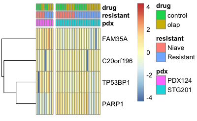

```r
#genes <- c("FAM35A","C20orf196","TP53BP1","RIF1","DYNLL1","TEN1","PARG","PARP1","MATN1")
genes <- c("FAM35A","C20orf196","TP53BP1","PARP1")
genes.ensembl <- getBM(attributes=c('ensembl_gene_id',"external_gene_name"),filters='external_gene_name',mart=hg19.ensembl,values=genes)
i <- match(genes.ensembl$ensembl_gene_id,rownames(DE.data$v$E))
genes.ensembl <- genes.ensembl[!is.na(i),]
i <- i[!is.na(i)]
x <- DE.data$v$E[i,]
#x <- removeBatchEffect(x, batch=sequencing))
rownames(x) <- genes.ensembl$external_gene_name
i <- rnaseq$meta[,order(pdx,resistant,drug)]
x.meta <- rnaseq$meta[i]
x <- x[,i]
ann.col <- as.data.frame(x.meta[,.(pdx,resistant,drug)])
rownames(ann.col) <- colnames(x)
labels.col <- rep("",ncol(x))
pheatmap(x,labels_col=labels.col,annotation_col = ann.col,cluster_cols = F,gaps_col=c(10),scale = "row")
```

[figure not shown]

```r
genes <- c("FAM35A","C20orf196","TP53BP1","PARP1","BRCA1")
genes.ensembl <- getBM(attributes=c('ensembl_gene_id',"external_gene_name"),filters='external_gene_name',mart=hg19.ensembl,values=genes)
i <- match(genes.ensembl$ensembl_gene_id,rownames(DE.data$v$E))
genes.ensembl <- genes.ensembl[!is.na(i),]
i <- i[!is.na(i)]
x <- DE.data$v$E[i,]
#x <- removeBatchEffect(x, batch=sequencing))
genes.ensembl[genes.ensembl$external_gene_name == "TP53BP1",]$external_gene_name <- "53BP1"
rownames(x) <- genes.ensembl$external_gene_name
i <- rnaseq$meta[,pdx=="STG201"]
x <- x[,i]
x.meta <- rnaseq$meta[i]
x <- t(scale(t(x)))
#i <- x.meta[,resistant=="Resistant"]
#x <- x[,i]
#x.meta <- x.meta[i]
i <- x.meta[,order(pdx,resistant,drug,oscar.number)]
x.meta <- x.meta[i]
x <- x[,i]
x.meta$drug <- factor(x.meta$drug)
levels(x.meta$drug) <- c("Control","Olaparib")
ann.col <- as.data.frame(x.meta[,.(Drug=drug,Resistance=resistant)])
rownames(ann.col) <- colnames(x)
#labels.col <- x.meta[,ifelse(is.na(oscar.number),Sample.name,oscar.number)]
labels.col <- x.meta[,Sample.name]
#labels.col <- rep("",ncol(x))
pheatmap(x,labels_col=labels.col,annotation_col = ann.col,cluster_cols = F,cluster_rows=F,scale = "none",cellwidth = 15, cellheight = 15, annotation_names_col=F, breaks=seq(-4.5,2.5,length.out = 100), color = rev(colorRampPalette(brewer.pal(7,"RdYlBu"))(100)),border_color = "grey30",gaps_col = c(6,rep(11,4),18))
```

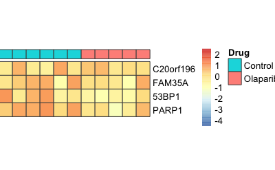

```r
genes <- c("FAM35A","C20orf196","TP53BP1","PARP1")
genes.ensembl <- getBM(attributes=c('ensembl_gene_id',"external_gene_name"),filters='external_gene_name',mart=hg19.ensembl,values=genes)
i <- match(genes.ensembl$ensembl_gene_id,rownames(DE.data$v$E))
genes.ensembl <- genes.ensembl[!is.na(i),]
i <- i[!is.na(i)]
x <- DE.data$v$E[i,]
#x <- removeBatchEffect(x, batch=sequencing))
genes.ensembl[genes.ensembl$external_gene_name == "TP53BP1",]$external_gene_name <- "53BP1"
rownames(x) <- genes.ensembl$external_gene_name
i <- rnaseq$meta[,pdx=="STG201"]
x <- x[,i]
x.meta <- rnaseq$meta[i]
x <- t(scale(t(x)))
i <- x.meta[,resistant!="Resistant"]
x <- x[,i]
x.meta <- x.meta[i]
i <- x.meta[,order(pdx,resistant,drug,oscar.number)]
x.meta <- x.meta[i]
x <- x[,i]
x.meta$drug <- factor(x.meta$drug)
levels(x.meta$drug) <- c("Control","Olaparib")
ann.col <- as.data.frame(x.meta[,.(Drug=drug)])
rownames(ann.col) <- colnames(x)
#labels.col <- x.meta[,ifelse(is.na(oscar.number),Sample.name,oscar.number)]
labels.col <- rep("",ncol(x))
pheatmap(x,labels_col=labels.col,annotation_col = ann.col,cluster_cols = F,cluster_rows=F,scale = "none",cellwidth = 15, cellheight = 15, annotation_names_col=F, breaks=seq(-4.5,2.5,length.out = 100), color = rev(colorRampPalette(brewer.pal(7,"RdYlBu"))(100)),border_color = "grey30")
```

This model makes no presumptions about how the drug interacts w.r.t. resistance and PDX model. However, by constructing the model in such a manner, the increase in power to the above model means that we may find overlap in genes/pathways.

```r
topTable.annotated.DE(DE.data$efit,coef=2)
```

| ENSEMBL | logFC | AveExpr | t | P.Value | adj.P.Val | B | direction | ENTREZID | SYMBOL | GENENAME |
| --- | --- | --- | --- | --- | --- | --- | --- | --- | --- | --- |
| ENSG00000012048 | 7.0764734 | 2.527390720 | 21.525418 | 2.426309e-20 | 4.558306e-16 | 31.807966 | up.reg | 672 | BRCA1 | BRCA1, DNA repair associated |
| ENSG00000188290 | -2.8244782 | 4.972512947 | -13.377662 | 1.685132e-14 | 1.071692e-10 | 23.059197 | down.reg | 57801 | HES4 | hes family bHLH transcription factor 4 |
| ENSG00000251562 | 4.3985138 | 8.811275421 | 13.369966 | 1.711331e-14 | 1.071692e-10 | 22.952226 | up.reg | 378938 | MALAT1 | metastasis associated lung adenocarcinoma transcript 1 (non-protein coding) |
| ENSG00000177374 | -1.8776578 | 4.834884720 | -12.704818 | 6.652564e-14 | 2.499634e-10 | 21.728215 | down.reg | 3090 | HIC1 | HIC ZBTB transcriptional repressor 1 |
| ENSG00000167996 | -3.5114641 | 5.796448910 | -12.524854 | 9.687013e-14 | 2.774537e-10 | 21.359091 | down.reg | 2495 | FTH1 | ferritin heavy chain 1 |
| ENSG00000101084 | -3.8615575 | 3.104845338 | -12.705162 | 6.647810e-14 | 2.499634e-10 | 21.293375 | down.reg | 55969 | C20orf24 | chromosome 20 open reading frame 24 |
| ENSG00000105289 | -1.5860608 | 5.799201332 | -12.346834 | 1.409942e-13 | 3.311073e-10 | 20.974335 | down.reg | 27134 | TJP3 | tight junction protein 3 |
| ENSG00000272060 | 4.2446812 | 14.163877407 | 12.493889 | 1.033787e-13 | 2.774537e-10 | 20.791866 | up.reg | NA | NA | NA |
| ENSG00000141699 | 1.3780627 | 6.114944024 | 11.947096 | 3.319243e-13 | 6.928735e-10 | 20.093027 | up.reg | 162427 | RETREG3 | reticulophagy regulator family member 3 |
| ENSG00000165215 | -1.9908143 | 7.499174091 | -10.903473 | 3.396533e-12 | 5.317555e-09 | 17.681794 | down.reg | 1365 | CLDN3 | claudin 3 |

[output cut: 990 more lines]

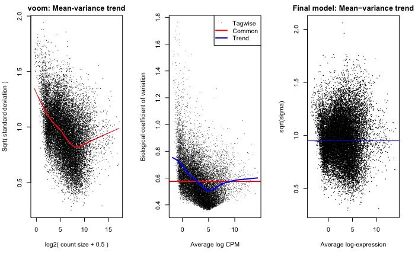

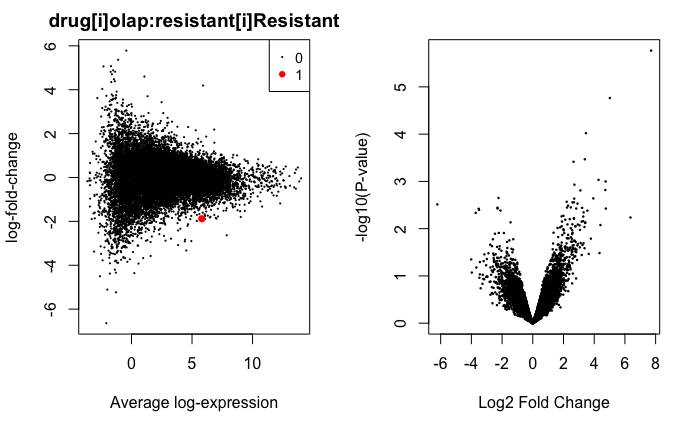

```r
i <- which(pdx!="STG201")
#d <- model.matrix(~ drug * resistant * pdx  + sequencing) The sequencing batch effect compounds the STG201OR vs STG201 comparison. We ignore it, but are naturally worried.
d <- model.matrix(~ drug[i] * resistant[i])
d <- d[,colSums(d)!=0]
#cont.matrix <- matrix(c(-1,1,rep(0,dim(d)[2]-2)), dim(d)[2], 1)
#colnames(cont.matrix) <- c("Olap.minus.control")
#rownames(cont.matrix) <- colnames(d)
#cont.matrix
coefs <- c(2,3,4)
#Perform DE
DE.data <- DE.run(rnaseq$human[,i],d,2,coefs = coefs)
```

```r
topTable.annotated.DE(DE.data$efit,coef=2)
```

```
No DE genes
```

| rn | V2 |
| --- | --- |